# EDA zestawu danych

Jakub Pączek

2023-11-14

## Wprowadzenie

Do przeprowadzenia EDA wybrałem zestaw danych dotyczących średniej długości życia oraz innych wskażników społecznych i ekonomicznych w poszczególnych krajach świata. W ramach projektu zamierzam dokonać analizy zbioru danych, zbadać dokładnie ich rozkład i współzależności.

### Źródła

Dane pochodzą w przeważającej cześci z *World Bank Open Data* oraz *Our World in Data*. Zostały one zebrane i są dostępne na witrynie *Kaggle* pod adresem:  
https://www.kaggle.com/datasets/mjshri23/life-expectancy-and-socio-economic-world-bank

### Pakiety z których będę korzystał

```r
library(dplyr)    # pakiet zawiera wiele przydatnych funkcji
library(ggplot2)  # pakiet do rysowania wykresów
library(moments)  # pakiet zawiera min. skośność, kurtozę
library(corrplot) # pakiet dodaje wykresy korelacji
```

### Wgrywanie danych

```r
dane <- read.csv(file = "life expectancy.csv")
```

## Przygotowanie danych

### Poszczególne zmiennie

Zestaw danych zawiera łącznie 16 zmiennych.

- `Country.Name` - nazwa kraju
- `Country.Code` - trzyliterowy skrót nazwy kraju
- `Region` - rejon świata gdzie znajduje się kraj
- `IncomeGroup` - klasa przychodu do jakiej kwalifikuje się kraj
- `Year` - lata od 2001 do 2019
- `Life.Expectancy.World.Bank` - oczekiwana długość życia ustalona przez Bank Światowy
- `Prevelance.of.Undernourishment` - procent populacji niedostatecznie dożywionej
- `CO2` - emisje dwutlenku węgla wyrażone w kilotonach. Obejmują min. spalanie paliw czy produkcję cementu.
- `Health.Expenditure` - wydatki na ochronę zdrowia jako procent PKB państwa
- `Education.Expenditure` - wydatki na edukację jako procent PKB państwa
- `Unemployment` - stopa bezrobocia
- `Corruption` - poziom korupcji, wskaźnik opracowany przez Bank Światowy
- `Sanitation` - procent populacji z dostępem do podstawowych udogodnień sanitarnych. Dane pochodzą ze źródła https://washdata.org
- `Injuries` - tzw. wskaźnik DALY, suma lat życia utraconych na rzecz urazów, niepełnosprawnośći i lat utraconych w wyniku przedwczesnej śmierci z tego powodu
- `Communicable` - to samo dla chorób zakaźnych
- `NonCommunicable` - to samo dla chorób niezakaźnych

### Typ danych

Skorzystam teraz z funkcji `str` by zobaczyć typ danych dla każdej zmiennej.

```r
str(dane)
```

```
## 'data.frame':    3306 obs. of  16 variables:
##  $ Country.Name                  : chr  "Afghanistan" "Angola" "Albania" "Andorra" ...
##  $ Country.Code                  : chr  "AFG" "AGO" "ALB" "AND" ...
##  $ Region                        : chr  "South Asia" "Sub-Saharan Africa" "Europe & Central Asia" "Europe & Central Asia" ...
##  $ IncomeGroup                   : chr  "Low income" "Lower middle income" "Upper middle income" "High income" ...
##  $ Year                          : int  2001 2001 2001 2001 2001 2001 2001 2001 2001 2001 ...
##  $ Life.Expectancy.World.Bank    : num  56.3 47.1 74.3 NA 74.5 ...
##  $ Prevelance.of.Undernourishment: num  47.8 67.5 4.9 NA 2.8 3 26.1 NA NA 2.5 ...
##  $ CO2                           : num  730 15960 3230 520 97200 ...
##  $ Health.Expenditure..          : num  NA 4.48 7.14 5.87 2.48 ...
##  $ Education.Expenditure..       : num  NA NA 3.46 NA NA ...
##  $ Unemployment                  : num  10.81 4 18.58 NA 2.49 ...
##  $ Corruption                    : num  NA NA NA NA NA NA NA NA NA NA ...
##  $ Sanitation                    : num  NA NA 40.5 21.8 NA ...
##  $ Injuries                      : num  2179727 1392081 117082 1698 144678 ...
##  $ Communicable                  : num  9689194 11190211 140895 696 65272 ...
##  $ NonCommunicable               : num  5795426 2663516 532325 13637 481741 ...
```

Pierwsze dwie zmienne mają typ `char`. Dwie następne, `Region` i `IncomeGroup` należy zamienić na typ `factor`. Reszta to zmienne liczbowe.

```r
dane$Region <- as.factor(dane$Region)
dane$IncomeGroup <- as.factor(dane$IncomeGroup)
str(dane[,c(3,4)]) # upewniam się czy dobrze zostały zamienione
```

```
## 'data.frame':    3306 obs. of  2 variables:
##  $ Region     : Factor w/ 7 levels "East Asia & Pacific",..: 6 7 2 2 4 3 2 1 3 1 ...
##  $ IncomeGroup: Factor w/ 4 levels "High income",..: 2 3 4 1 1 4 4 4 1 1 ...
```

### Braki w danych

Sprawdzę w których danych znajdują się braki. Posłużę się do tego funkcją `apply` i funckją, która liczyć będzie odsetek braków danych.

```r
miss <- function(x){round(sum(is.na(x))/length(x), 2)}
apply(dane, 2, miss)
```

```
##                   Country.Name                   Country.Code
##                           0.00                           0.00
##                         Region                    IncomeGroup
##                           0.00                           0.00
##                           Year     Life.Expectancy.World.Bank
##                           0.00                           0.06
## Prevelance.of.Undernourishment                            CO2
##                           0.21                           0.05
##           Health.Expenditure..        Education.Expenditure..
##                           0.05                           0.33
##                   Unemployment                     Corruption
##                           0.09                           0.71
##                     Sanitation                       Injuries
##                           0.38                           0.00
##                   Communicable                NonCommunicable
##                           0.00                           0.00
```

Widać, że zmienne o korupcji, wydatkach na edukacje i dostępności do udogodnień sanitarnych mają bardzo dużo braków. W każdym wypadku jest to ponad 1/3. Najlepiej więc będzie je pominąć i potem rozważyć czy i w jaki sposób uzwględnić je w analizie.

Co do pozostałych zmiennych to braki nie są bardzo duże. Postaram się je więc uzupełnić.

W przypadku danych na temat demografii i ekonomii państw braki najczęściej wynikać mogą na przykład z barier geograficznych i trudności z dostępem do niektórych regionów, autorytarnego ustroju, trwających wojen, konfliktów, klęsk żywiołowych, braku odpowiednich środków na badania czy braku inicjatywy do badań.

W każdym z powyższych przypadków braki te są typu MAR, czyli spowodowane są zdarzeniami losowymi. Wobec tego dobrym sposobem na ich eliminację będzie zastąpienie średnią. Użyję średniej dla danego roku i dla danego regionu świata.

Sprawdzę też przed i po operacji, ile braków zawiera zmienna.

- Oczekiwana długość życia

```r
sum(is.na(dane$Life.Expectancy.World.Bank))
```

```
## [1] 188
```

```r
dane <- dane %>%
  group_by(Region, Year) %>%
  mutate(Life.Expectancy.World.Bank =
           ifelse(is.na(Life.Expectancy.World.Bank),
                  mean(Life.Expectancy.World.Bank, na.rm = T),
                  Life.Expectancy.World.Bank)) %>%
  ungroup()
sum(is.na(dane$Life.Expectancy.World.Bank))
```

```
## [1] 0
```

- Poziom niedożywienia

```r
sum(is.na(dane$Prevelance.of.Undernourishment))
```

```
## [1] 684
```

```r
dane <- dane %>%
  group_by(Region, Year) %>%
  mutate(Prevelance.of.Undernourishment =
           ifelse(is.na(Prevelance.of.Undernourishment),
                  mean(Prevelance.of.Undernourishment, na.rm = T),
           Prevelance.of.Undernourishment)) %>%
  ungroup()
sum(is.na(dane$Prevelance.of.Undernourishment))
```

```
## [1] 0
```

- Emisja CO2

```r
sum(is.na(dane$CO2))
```

```
## [1] 152
```

```r
dane <- dane %>%
  group_by(Region, Year) %>%
  mutate(CO2 = ifelse(is.na(CO2), mean(CO2, na.rm = T),CO2)) %>%
  ungroup()
sum(is.na(dane$CO2))
```

```
## [1] 0
```

- Wydatki na opiekę zdrowotną

```r
sum(is.na(dane$Health.Expenditure..))
```

```
## [1] 180
```

```r
dane <- dane %>%
  group_by(Region, Year) %>%
  mutate(Health.Expenditure.. =
           ifelse(is.na(Health.Expenditure..),
                  mean(Health.Expenditure.., na.rm = T),
                  Health.Expenditure..)) %>%
  ungroup()
sum(is.na(dane$Health.Expenditure..))
```

```
## [1] 0
```

- Stopa bezrobocia

```r
sum(is.na(dane$Unemployment))
```

```
## [1] 304
```

```r
dane <- dane %>%
  group_by(Region, Year) %>%
  mutate(Unemployment =
           ifelse(is.na(Unemployment),
                  mean(Unemployment, na.rm = T),Unemployment)) %>%
  ungroup()
sum(is.na(dane$Unemployment))
```

```
## [1] 0
```

## Rozkład oczekiwanej długości życia

Zmienną na której skupia się zestaw danych jest oczekiwana długość życia czyli zmienna `Life.Expectancy.World.Bank`, więc poznanie jej rozkładu jest dla analizy danych najistotniejsze.

Oznacza ona przeciętną liczbę lat jaką przeżyłby noworodek, gdyby wszelakie uwarunkowania wpływające na nią były takie same przez całe jego życia jak w chwili narodzin.

Z racji iż nie wiemy co może wydarzyć się w trakcie jego życia zmienna ta nie służy do szacowania wieku populacji danego kraju, ale raczej jest jednym z kluczowych mierników ogólnego stanu zdrowia populacji w danym okresie.

Sprawdzę więc najpierw podstawowe statystyki opisowe za pomocą funkcji `summary`. Wzięty tu pod uwagę będzie cały badany okres czyli lata 2001 - 2019.

```r
summary(dane$Life.Expectancy.World.Bank)
```

```
##    Min. 1st Qu.  Median    Mean 3rd Qu.    Max.
##   40.37   64.22   72.38   69.96   76.67   84.36
```

Wnioski:

- Przeciętna długość życia człowieka biorąc pod uwagę cały świat w rozpatrywanym okresie wynosiła około 70 lat.
- Mediana jest większa o około 2 od średniej oraz odległość 1 kwartyla do mediany jest większa niż mediany do 3 kwartyla. Obie te rzeczy świadczyć mogą o lewostronnej skośności rozkładu. Dla potwierdzenia wyznaczę współczynnik skośności.

```r
skewness(dane$Life.Expectancy.World.Bank)
```

```
## [1] -0.8424844
```

Jest on wyraźnie ujemny, co potwierdza mój powyższy wniosek.

- Najmniejsza wartość jaką przyjmuje zmienna to nieco ponad 40 lat, a największa to ponad 84.

### Jak zmienia się oczekiwana długość życia na przestrzeni lat?

Jest to pierwsze i chyba najistotniejsze z pytań jakie należy zadać. Odpowiem na to pytanie korzystając z wykresów pudełkowych z wąsem.

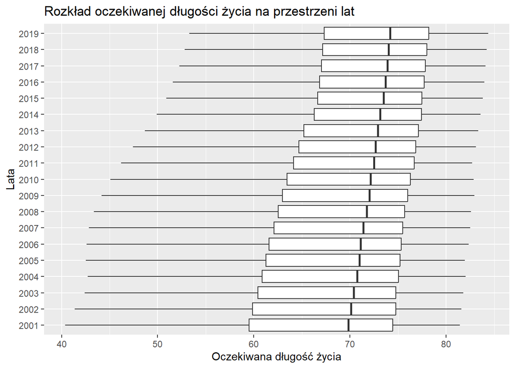

```r
dane %>%
  ggplot(aes(x = Life.Expectancy.World.Bank, y = as.factor(Year))) +
  geom_boxplot() +
  labs(title = "Rozkład oczekiwanej długości życia na przestrzeni lat",
       x = "Oczekiwana długość życia",
       y = "Lata")
```

Wnioski:

- Zauważamy przede wszystkim, że przeciętna długość życia z roku na rok rośnie.
- Szerokość pudełka, czyli rozstęp międzykwartylowy z roku na rok maleje. Zatem oczekiwana długość życia na całym świecie dąży do ujednolicenia.
- Maksymalna i oczekiwana długość też przeciętnie ciągle rosną, lecz wartość minimalna rośnie szybciej i w mniej jednorodnym tempie.

### Czy oczekiwana długość życia zależna jest od regionu świata?

Naturalnym byłoby, gdyby uboższe regiony miały faktycznie wartość tej zmiennej zaniżoną w stosunku do bogatszych.

Sprawdzę, używając funkcji `summarize` i funkcji `mean` czy średnia oczekiwana długość życia różni się w zależności od regionu.

```r
dane %>%
  group_by(Region) %>%
  summarise(Średnie = mean(Life.Expectancy.World.Bank)) %>%
  arrange(desc(Średnie))
```

```
## # A tibble: 7 × 2
##   Region                     Średnie
##   <fct>                        <dbl>
## 1 North America                 79.7
## 2 Europe & Central Asia         76.2
## 3 Middle East & North Africa    74.6
## 4 Latin America & Caribbean     73.6
## 5 East Asia & Pacific           72.1
## 6 South Asia                    68.5
## 7 Sub-Saharan Africa            57.5
```

## Rozkład pozostałych zmiennych

Grupa przychodów jest zmienną kategoryczną. Podsumuję ją więc funkcją `table`.

```r
table(dane$IncomeGroup)
```

```
##
##         High income          Low income Lower middle income Upper middle income
##                1083                 437                 855                 931
```

Pozostałe zmienne mają charakter ilościowy. Ich rozkład zbadam wykorzystując funkcję `summary`.

```r
summary(dane[,7:16])
```

```
##  Prevelance.of.Undernourishment      CO2           Health.Expenditure..
##  Min.   : 2.50                  Min.   :      10   Min.   : 1.264
##  1st Qu.: 2.60                  1st Qu.:    2183   1st Qu.: 4.305
##  Median : 7.40                  Median :   12080   Median : 5.987
##  Mean   :11.06                  Mean   :  176738   Mean   : 6.398
##  3rd Qu.:16.20                  3rd Qu.:   71360   3rd Qu.: 8.052
##  Max.   :70.90                  Max.   :10707220   Max.   :24.231
##
##  Education.Expenditure..  Unemployment      Corruption      Sanitation
##  Min.   : 0.8503         Min.   : 0.100   Min.   :1.000   Min.   :  2.378
##  1st Qu.: 3.1361         1st Qu.: 3.730   1st Qu.:2.500   1st Qu.: 24.746
##  Median : 4.3715         Median : 5.956   Median :3.000   Median : 49.318
##  Mean   : 4.5890         Mean   : 7.752   Mean   :2.861   Mean   : 52.739
##  3rd Qu.: 5.5198         3rd Qu.: 9.873   3rd Qu.:3.250   3rd Qu.: 80.279
##  Max.   :23.2700         Max.   :37.250   Max.   :4.500   Max.   :100.000
##  NA's   :1090                             NA's   :2331    NA's   :1247
##     Injuries         Communicable       NonCommunicable
##  Min.   :     430   Min.   :      330   Min.   :     2482
##  1st Qu.:   62457   1st Qu.:    57765   1st Qu.:   318476
##  Median :  245691   Median :   314769   Median :  1350146
##  Mean   : 1318219   Mean   :  4686289   Mean   :  7392488
##  3rd Qu.:  846559   3rd Qu.:  2831636   3rd Qu.:  3918468
##  Max.   :55636759   Max.   :268564610   Max.   :324637810
##
```

Warte uwagi spostrzeżenia:

- Odsetek osób niedożywionych osiąga w badanym okresie poziom maksymalnie 70%.
- Emisja dwutlenku węgla jest bardzo zróżnicowana, co może być spowodowane min. przez znacznie różnice w rozwinięciu gospodarki danego państwa.
- Wydatki na ochronę zdrowia i edukację osiągają przeciętne kilka procent PKB.
- Warunki sanitarne w dużym stopniu różnią się w zależności od kraju.
- Z trzech grup kondycji zdrowotnych uzwględnionych w danych choroby inne niż zakażne są najliczniejsze.

### Czy rozkład grupy przychodów ma związek z regionem?

Podział państw na grupy przychodu oparty jest na PKB per capita, a więc na zamożności społeczeństwa. Logicznym więc wydaje się, że biedniejsze regiony powinny być kwalifokowane do niższych grup.

Odpowiem na to pytanie używając wykresu słupkowego gęstości. Dla uproszczenia rozpatrzę tylko dane z 2019 roku, grupa przychodu jest czymś, co ciężko zmienić na przestrzeni kilunastu lat.

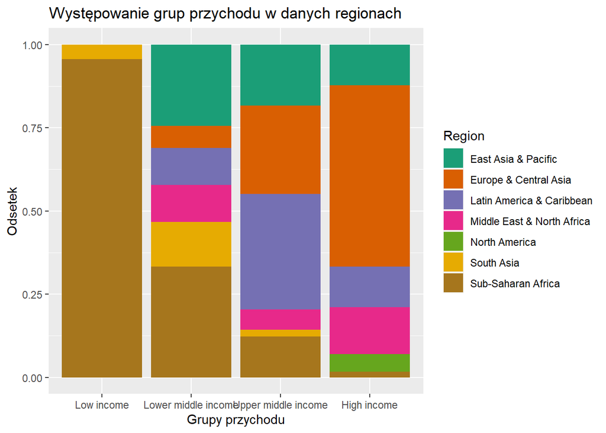

```r
dane %>%
  filter(Year == 2019) %>%
  ggplot(aes(fill = Region,
             x = factor(IncomeGroup,level = c("Low income", "Lower middle income", "Upper middle income", "High income")))) +
  geom_bar(position = "fill") +
  scale_fill_brewer(palette="Dark2") +
  labs(title = "Występowanie grup przychodu w danych regionach",
       x = "Grupy przychodu",
       y = "Odsetek")
```

Wnioski:

- Region świata ma istotny wpływ na rozkład klas przychodu.
- W grupie najniższego przychodu są prawie wyłącznie kraje Afryki Subsaharyjskiej.
- W grupie najwyższego przychodu dominują kraje europejskie.
- Grupa niższego średniego przychodu jest najmocniej zróżnicowana.

### Korelacja między zmiennymi

Wyświetlę teraz macierz korelacji Spearmana między zmiennymi liczbowymi, które nie mają braków w danych.

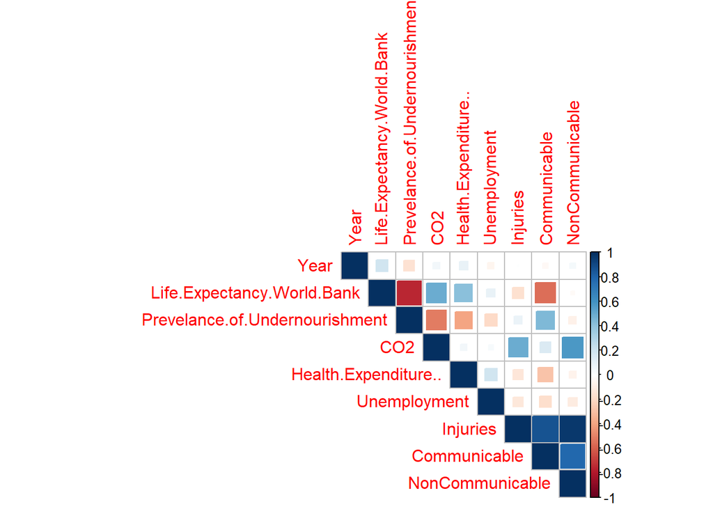

```r
cor <- cor(dane[,c(5:9,11,14:16)], method = "spearman")
corrplot(cor, method = "square", type = "upper")
```

- Nie we wszystkich przypadkach zmienne są ze sobą skorelowane.
- Oczkiewana długość życia i poziom niedożywienia posiadają korelację ze znaczną częścią zmiennych.
- Emisja dwutlenku węgla jest skorelowana z chorobami.

## Zależności oczekiwanej długości życia z innymi zmiennymi

### Czy niedożywienie wpływa na zmniejszenie oczekiwanej długości życia?

Do odpowiedzi użyję ponownie korelacji rangowanej Spearmana, gdyż nie mogę założyć, że zależność jest liniowa.

```r
dane %>%
  group_by(Year) %>%
  summarize(Korelacja = round(cor(Life.Expectancy.World.Bank, Prevelance.of.Undernourishment, method = "spearman"),4))
```

```
## # A tibble: 19 × 2
##     Year Korelacja
##    <int>     <dbl>
##  1  2001    -0.762
##  2  2002    -0.761
##  3  2003    -0.748
##  4  2004    -0.740
##  5  2005    -0.730
##  6  2006    -0.732
##  7  2007    -0.730
##  8  2008    -0.74
##  9  2009    -0.745
## 10  2010    -0.748
## 11  2011    -0.750
## 12  2012    -0.744
## 13  2013    -0.754
## 14  2014    -0.755
## 15  2015    -0.752
## 16  2016    -0.750
## 17  2017    -0.745
## 18  2018    -0.742
## 19  2019    -0.730
```

Wnioski:

- W całym badanym okresie korelacja utrzymuje się na podobnym poziomie równym około -0.74.
- Statystyka ta świadczy o silnej negatywnej zależności, czyli im mniejsze niedożywienie tym większa oczekiwana długość życia i na odwrót.

### Czy większa emisja CO2 przyczynia się do zwiększenia oczekiwanej długości życia?

Ten problem wydaje się być bardziej złożony od poprzedniego i nie posiadać jednoznacznej odpowiedzi. Na macierzy korelacji widzieliśmy, że zależność biorąc pod uwagę cały badany okres i kraje całego świata ogólnie współczynnik korelacji jest dodatni, co wskazywało by że im więcej dwutlenku węgla w atmosferze tym ludzie żyją dłużej. Wydaje się to nienaturalne, gdyż zanieczyszczenie ma zawsze negatywny wpływ na nasze zdrowie. Poniżej policzę jednak współczynniki korelacji dla wybranych krajów z każdego kontynentu.

```r
dane %>%
  filter(Country.Name %in% c("Germany", "India", "United States", "Brazil", "Tanzania", "New Zealand")) %>%
  group_by(Country.Name) %>%
  summarize(Korelacja = cor(Life.Expectancy.World.Bank, CO2, method = "spearman"))
```

```
## # A tibble: 6 × 2
##   Country.Name  Korelacja
##   <chr>             <dbl>
## 1 Brazil           0.865
## 2 Germany         -0.904
## 3 India            1
## 4 New Zealand     -0.0921
## 5 Tanzania         0.988
## 6 United States   -0.782
```

Widzimy, że są kraje gdzie w danych mamy bardzo silną pozytywną korelację, a w innych jest zupełnie na odwrót, lub też zmienne nie są skorelowane.

Wynikać to może z tego, co uważam za najbardziej prawdopodbne, że oczekiwana długość życia jest w dużo większym stopniu powiazana z rozwojem gospodarczym kraju. A on wpływa też zupełnie niezależnie na wzrost emisji dwutlenku węgla przez rozwój przemysłu.

Na dwóch wykresach postaram się pokazać jak sytuacja ma się w krajach silnie rozwijających się i w krajach już wysoko rozwiniętych.

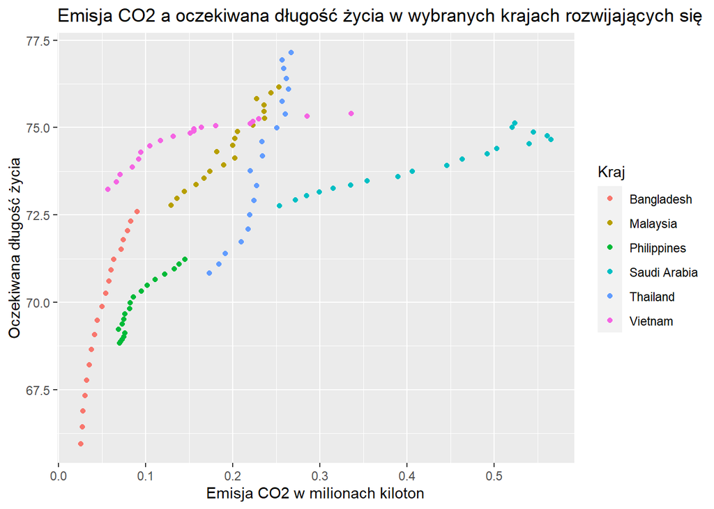

```r
dane %>%
  filter(Country.Name %in% c("Thailand", "Vietnam", "Philippines", "Malaysia", "Saudi Arabia","Bangladesh")) %>%
  ggplot(aes(x = CO2/1000000, y = Life.Expectancy.World.Bank, color = Country.Name)) +
  geom_point() +
  labs(title = "Emisja CO2 a oczekiwana długość życia w wybranych krajach rozwijających się",
       x = "Emisja CO2 w milionach kiloton",
       y = "Oczekiwana długość życia",
       color = "Kraj")
```

- Wraz ze wzrostem emisji CO2 (co wskazuje na wzrost gospodarczy) rośnie też oczekiwana długość życia.

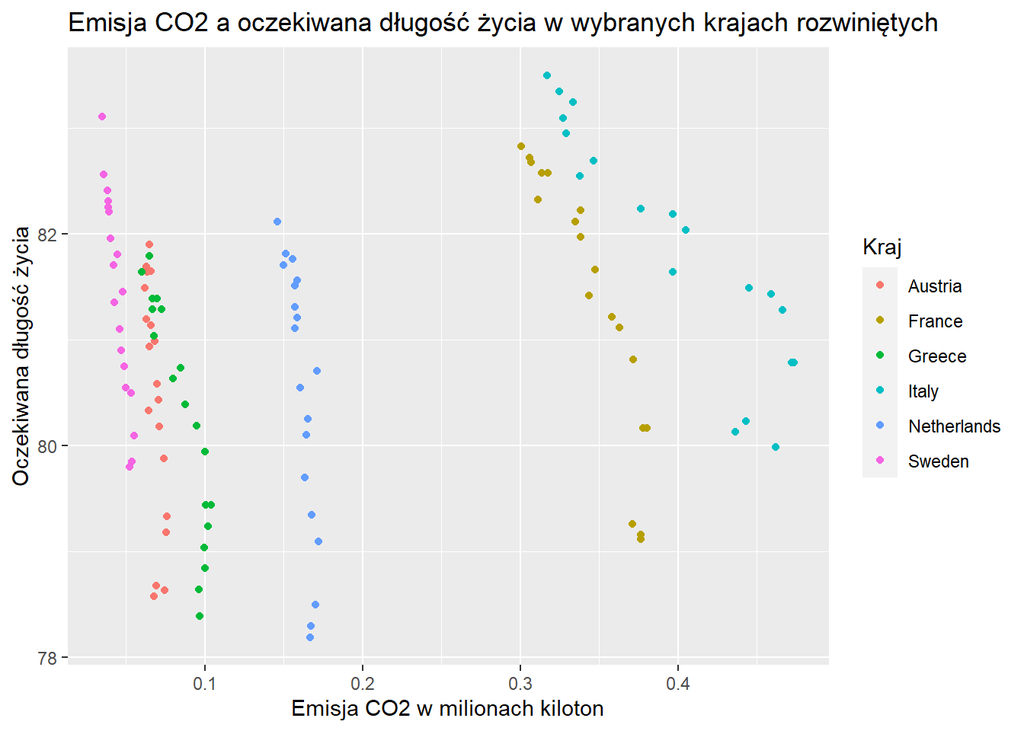

```r
dane %>%
  filter(Country.Name %in% c("Sweden", "Greece", "France", "Netherlands", "Austria", "Italy")) %>%
  ggplot(aes(x = CO2/1000000, y = Life.Expectancy.World.Bank, color = Country.Name)) +
  geom_point() +
  labs(title = "Emisja CO2 a oczekiwana długość życia w wybranych krajach rozwiniętych",
       x = "Emisja CO2 w milionach kiloton",
       y = "Oczekiwana długość życia",
       color = "Kraj")
```

- Kraje wysoko rozwinięte dążą do zmniejszenia emisji CO2, zwiększeniu natomiast, ale mniej znacznemu ulega oczekiwana długość życia.
- Krajów rozwijających się jest na świecie dużo więcej, co tłumaczyć może dodatnią korelację dla ogółu.
- W żadnym z tych przypadków nie jesteśmy jednak w stanie stwierdzić, czy emisja CO2 wywiera wpływ na oczekiwaną długość życia.

### Czy wyższe wydatki na ochronę zdrowia wyraźnie zwiększają długość życia?

W odpowiedzi na to pytanie narusyję wykres. Umieszczę na nim także linię trendu za pomocą komendy `geom_smooth`.

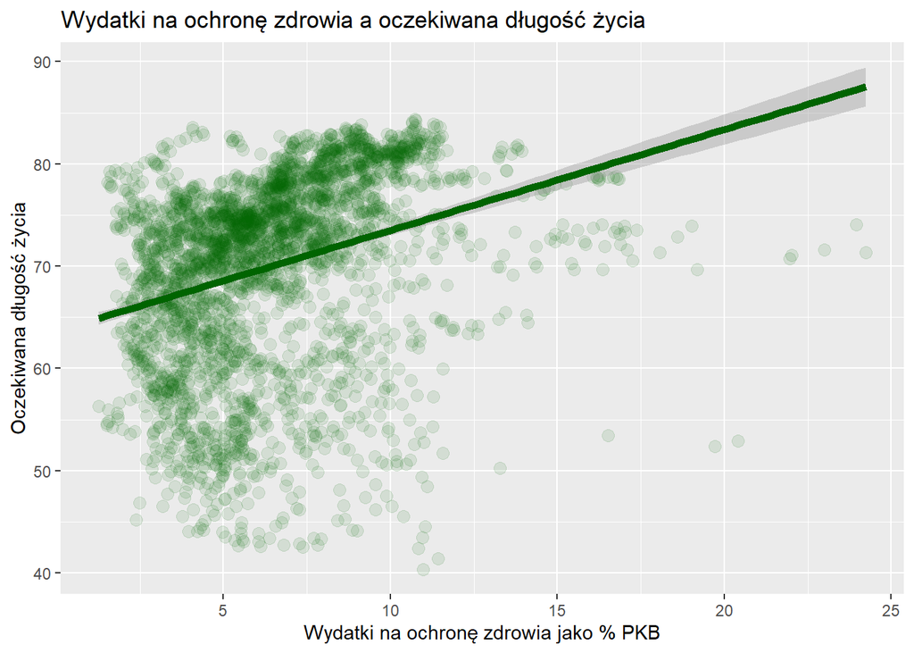

```r
dane %>%
  ggplot(aes(x = Health.Expenditure.., y = Life.Expectancy.World.Bank)) +
  geom_point(size = 3, alpha = 0.1, color = "darkgreen") +
  geom_smooth(formula = 'y ~ x', method = "lm", color = "darkgreen", linewidth = 2) +
  labs(title = "Wydatki na ochronę zdrowia a oczekiwana długość życia",
       x = "Wydatki na ochronę zdrowia jako % PKB",
       y = "Oczekiwana długość życia")
```

Wnioski:

- Im państwo wydaje więcej na ochronę zdrowia, tym ludzie żyją dłużej, lecz zależność ta nie jest w aż tak dużym stopniu zauważalna.

### Czy występowanie chorób zakaźnych ma w dużym stopniu wpływ na długość życia?

Zmienna, którą teraz chce uwzględnić oznacza łączną liczbę lat życia, w trakcie których obywatele chorowali na jakieś choroby zakaźne i lata, które zostały im zabrane w wyniku przedwcześnej śmierci z powodu chorób zakaźnych.

Zmienna jak było widać, jest ujemnie skorelowana z długością życia. Przewiduję, że zależność ta będzie najbardziej znacząca w najbiedniejszych regionach. W analizowanych danych, jak wcześniej ustaliłem najbiedniejszym regionem jest Afryka Subsaharyjska. Sporządzę więc wykres, który będzie brał pod uwagę 6 krajów z największą liczbą chorób zakaźnych z każdego roku.

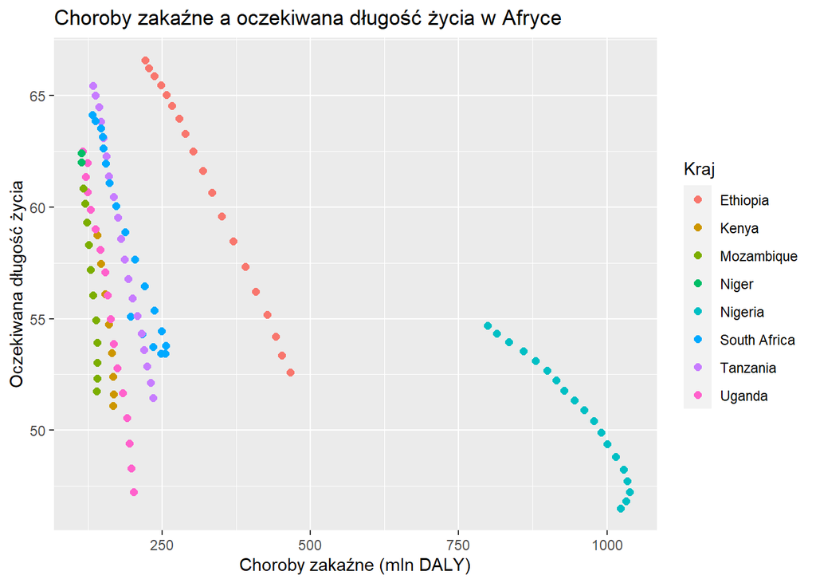

```r
dane %>%
  filter(Region == "Sub-Saharan Africa") %>%
  group_by(Year) %>%
  top_n(6, Communicable) %>%
  ggplot(aes(x = Communicable / 100000, y = Life.Expectancy.World.Bank, color = Country.Name)) +
  geom_point(size = 2) +
  labs(title = "Choroby zakaźne a oczekiwana długość życia w Afryce",
       x = "Choroby zakaźne (mln DALY)",
       y = "Oczekiwana długość życia",
       color = "Kraj")
```

Wnioski:

- Zależność na przykładzie tych kilku krajów jest dostrzegalna. W przypadku jednak bardziej zamożnych krajów, gdzie chorób zakaźnych nie jest dużo, zależność ta może być słabiej dostrzegalna.

## Inne zależności

### Czy wysokie niedożywienie przyczynia się do powstawania chorób zakaźnych?

Niedożywienie organizmu wiąże się z niemożnością dostarczenia niezbędnych minerałów i substancji odżywczych, na skutek czego znaczemu pogorszeniu ulega odporność organizmu, co wskazywałoby na większą liczbę chorób zakaźnych.

Postaram się to sprawdzić licząc podstawowe statystyki opisowe, średnią arytmetyczną, medianę, odchylenie standardowe i współczynnik korelacji Spearmana obu zmiennych osobno dla każdego roku badania.

```r
dane %>%
  group_by(Year) %>%
  summarize(Śr.nied = round(mean(Prevelance.of.Undernourishment), 2),
            Śr.chor = round(mean(Communicable),2),
            Med.nied = round(median(Prevelance.of.Undernourishment),2),
            Med.chor. = round(median(Communicable),2),
            Odch.nied = round(sd(Prevelance.of.Undernourishment),2),
            Odch.chor = round(sd(Communicable),2),
            Kor. = round(cor(Prevelance.of.Undernourishment, Communicable, method = "spearman"),2))
```

```
## # A tibble: 19 × 8
##     Year Śr.nied  Śr.chor Med.nied Med.chor. Odch.nied Odch.chor  Kor.
##    <int>   <dbl>    <dbl>    <dbl>     <dbl>     <dbl>     <dbl> <dbl>
##  1  2001   14.5  5754158.    10.2    374188.     13.0  22930092.  0.49
##  2  2002   14.1  5663251.     9.52   360826.     12.8  22434059.  0.5
##  3  2003   13.8  5569551.     9.42   357757.     12.5  21938181.  0.49
##  4  2004   13.4  5469024.     9.05   351713.     12.1  21528817.  0.5
##  5  2005   12.8  5362045.     9.3    346751.     11.7  21181150.  0.49
##  6  2006   12.2  5231974.     9.15   337055.     11.2  20681407.  0.49
##  7  2007   11.8  5087628.     9.1    328601.     10.8  20134349.  0.48
##  8  2008   11.4  4952179.     8.65   322219.     10.6  19626981.  0.48
##  9  2009   10.8  4806304.     7.9    313024.      9.92 18937765.  0.47
## 10  2010   10.2  4680422.     7.5    313034.      9.38 18376729.  0.46
## 11  2011    9.59 4554252.     7.2    317856.      8.95 17860873.  0.44
## 12  2012    9.41 4408253.     6.95   307637.      8.84 17200458.  0.42
## 13  2013    9.34 4286449.     6.75   302603.      8.89 16633388.  0.41
## 14  2014    9.4  4164197.     6.6    299227.      9.19 15933345.  0.4
## 15  2015    9.47 4053974.     6.5    295058.      9.43 15375729.  0.39
## 16  2016    9.47 3920914.     6.5    290594.      9.52 14531110.  0.39
## 17  2017    9.42 3799241.     6.37   284642.      9.51 13985227.  0.38
## 18  2018    9.4  3682408.     6.2    279577.      9.59 13597414.  0.38
## 19  2019    9.66 3593261.     6.39   274998.      9.9  13207429.  0.39
```

### Czy bezrobocie zależy od grupy przychodu i regionu świata?

Zmienną, którą do tej pory słabo rozpatrzyłem jest bezrobocie. Nie posiada ono jednak istotnych korelacji z innymi zmiennymi liczbowymi. Sprawdzę więc jego zależność z dwiem zmiennymi kategorycznymi, to jest grupą przychodu i regionem świata. Zobrazuję to za pomocą histogramów.

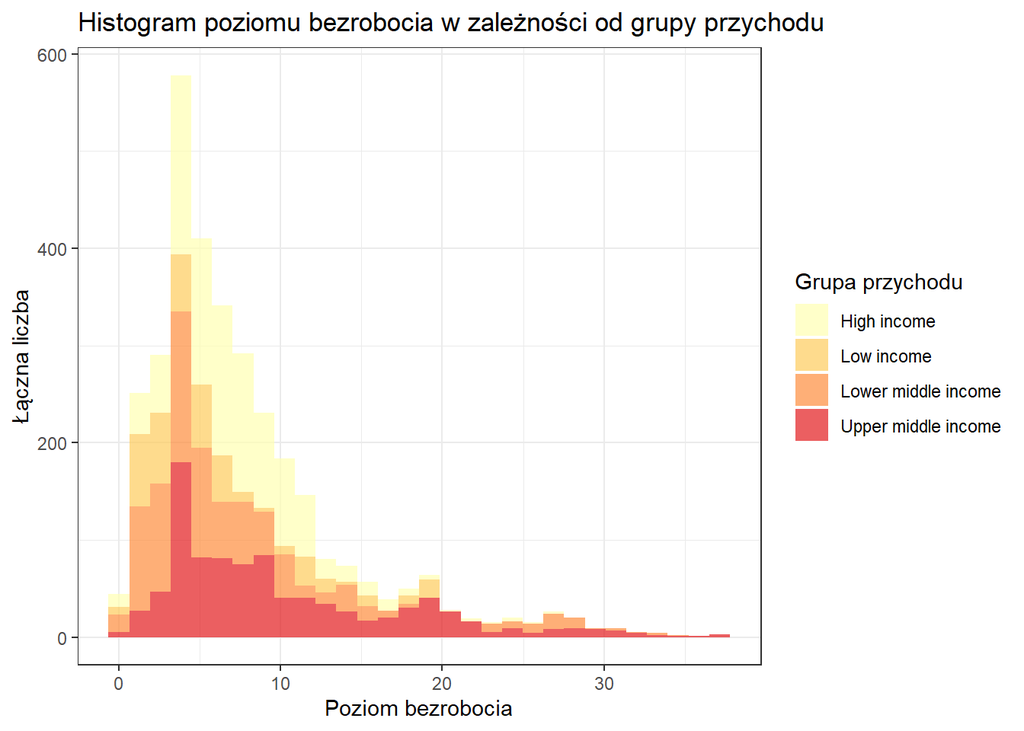

```r
dane %>%
  ggplot(aes(x = Unemployment, fill = IncomeGroup)) +
  geom_histogram(alpha = 0.7, bins = 30) +
  theme_bw() +
  scale_fill_brewer(palette = "YlOrRd") +
  labs(title = "Histogram poziomu bezrobocia w zależności od grupy przychodu",
       x = "Poziom bezrobocia", y = "Łączna liczba", fill = "Grupa przychodu")
```

Wnioski:

- Wszystkie rozkłady posiadają dominantę w tym samym przedziale około 3-4 pp.
- Wszystkie rozkłady są skośne prawostronnie.
- Grupy przychodu różnią się między sobą liczbą krajów, a więc i liczbą obserwacji, lecz dla każdej z nich kształty rozkładu nieznacznie się od siebie różnią.
- Stwierdzić więc można, że bezrobocie w bardzo niewielkim stopniu zależy od grupy przychodu.

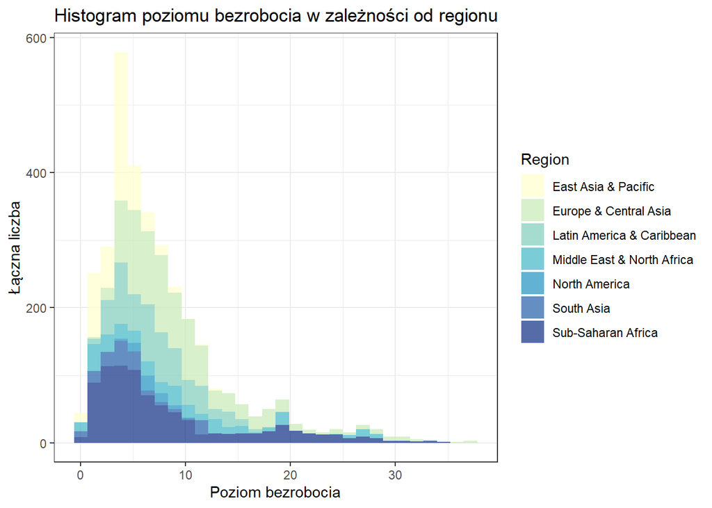

```r
dane %>%
  ggplot(aes(x = Unemployment, fill = Region)) +
  geom_histogram(alpha = 0.7, bins = 30) +
  theme_bw() +
  scale_fill_brewer(palette = "YlGnBu") +
  labs(title = "Histogram poziomu bezrobocia w zależności od regionu",
       x = "Poziom bezrobocia", y = "Łączna liczba")
```

Wnioski:

- Tutaj również można zauważyć, że moda znajduje się w tym samym przedziale.
- Też i tu niezależnie od regionu rozkład jest prawostronnie skośny.
- Regiony, co naturalne, różnią się między sobą liczebnością krajów.
- Podobnie wyglądające rozkłady wskazują, że między poziomem bezrobocia a regionem różnież nie występuje istotna zaleźność.

### Czy rozkłady łączych lat chorób i urazów są ze sobą powiązane?

Trzy ostatnie zmienne są to tak zwane wskaźniki DALY opracowane przez WHO. Oznaczają sum liczby utraconych lat w zdrowiu lub lat utraconych w wyniku przedwczesnej śmierci wywołanej daną chorobą, inwalidztwem. Wskaźnik ten rozpatrzony jest w danych dla urazów, chorób zakaźnych oraz innych niż zakaźne.

Są to zmienne liczbowe, więc by sprawdzić zależność zastosuję współczynnik korelacji Spearmana. Pogrupuję też dane najpierw według regionu, a potem według grupy przychodu.

```r
dane %>%
  group_by(Region) %>%
  summarize("Urazy i zak." = round(cor(Injuries, Communicable, method = "spearman"),4),
            "Urazy i niezak." = round(cor(Injuries, NonCommunicable, method = "spearman"),4),
            "Zak. i niezak." = round(cor(Communicable, NonCommunicable, method = "spearman"),4))
```

```
## # A tibble: 7 × 4
##   Region                     `Urazy i zak.` `Urazy i niezak.` `Zak. i niezak.`
##   <fct>                               <dbl>             <dbl>            <dbl>
## 1 East Asia & Pacific                 0.971             0.991            0.963
## 2 Europe & Central Asia               0.907             0.976            0.893
## 3 Latin America & Caribbean           0.963             0.974            0.927
## 4 Middle East & North Africa          0.811             0.931            0.820
## 5 North America                       0.940             0.931            0.866
## 6 South Asia                          0.970             0.961            0.964
## 7 Sub-Saharan Africa                  0.932             0.962            0.933
```

Wnioski:

- W każdym przypadku widzimy silną dodatnią korelację. Należy jednak pamiętać, że wynikać ona może z faktu, że im większa populacja kraju tym wskaźniki DALY większe, zatem duża wartość jednej zmiennej może automatycznie pociągać wyższą wartość drugiej.
- Najsilniejsza wydaje się być zależność między urazami chorobami niezakaźnymi.
- Można zaobserwować, że w bogatyszych regionach zależność chorób zakaźnych z niezakaźnymi jest nieco mniejsza (mniejsza od 0.9), lecz na ogół różnice między regionami są w niewielkim stopniu zauważalne.

## Podsumowanie

W ramach przeprowadzonej EDA skupiłem się na analizie rozkładu i zależnośći oczekiwanej długości życia, gdyż jest to najważniejsza zmienna zawarta w danych. Uwzględniłem też jednak pozostałe zmienne. Starałem się też w jakimś stopniu opisać i wytłumaczyć otrzymane wyniki.